# R Lecture 6 - Regression

# Regression Methods

Predictor variable (independent variable or covariate)

Response variable (dependent variable)

Goals:

- *Establish* a relationship (testing for regression, *Inference*)
- Develop appropriate model to *describe* relationship between predictors and responses (*Description*)
- Predict responses for new cases (*Prediction*)

Type of variables:

| Independent | Dependent: binary | count | multinomial | continuous |
| --- | --- | --- | --- | --- |
| binary (0/1) | 2 by 2 table or binary reg. | Poisson reg. | multinomial reg. | t-test |
| nomial | log-linear or binary reg. | Poisson reg. | multinomial reg. | ANOVA |
| continuous | binary reg. | Poisson reg. | multinomial reg. | multiple reg. |

## Regression

The simplest type of linear model:

Predicts the value of one numeric variable from another via “line of best fit”

Least squares approach: Find the line which minimizes the sum of squared residuals `lm(Y ~ X, data = <data frame>)`, `summary( lm(Y~X) )`

`ggplot( data, aes(x = x, y = y) ) + geom_point() + geom_smooth( method = "lm" )`

#### alternative way

```r
y <- rnorm( 5 )
x <- rnorm( 5 )
library(broom)
fit <- lm( y~x )
tidy( fit ) #gives you a data.frame representation
glance( fit ) #summary statistics computed for the entire regression
augment( fit )  #fitted results, residuals
```

References: https://cran.r-project.org/web/packages/broom/vignettes/broom.html

- `lm( Y ~ x + x1 + x2, data = data )`, with three independent predictors
- `lm( Y ~ x*x1, data = data )`, with an interaction effect
- `lm( Y ~ x + x1 + x:x1, data = data )`, with an interaction effect, written more verbosely
- `lm( Y ~ ., data = data )`, to include all other columns as predictors
- `predict( model, new.data )`, predict new case
- `predict( model, new.data, interval = "confidence", level=0.95 )`, construct CI
- `predict( model, new.data, interval = "predict",level=0.95 )`, construct PI

Assumptions and diagnostics: (從重要到不重要)

- Validity: 資料要能解決你有興趣的問題，結果要能正確呈現你的興趣問題的現象，選對變數
- Additivity and linearity: y和x要有線性關係，變數是否需要轉換，是否要加交互作用或其他變數
- Independence of errors
- Equal variance of errors
- Normality of errors

General principles:

1. 只放有存在意義、期望會對預測結果有用的變數
2. 不是每個變數都要分別放，可以把幾個變數加總或平均，當作一個新變數，放這個就好
3. 當這變數有large effect, 要考慮將交互作用也放進
4. 用“expected sign”和“statistical siginificance”來考慮要不要放這變數
- if a predictor is not statistically sig. and has the expected sign, it’s fine to keep it in.
- if a predictor is not statistically sig. and does not have the expected sign, consider removing it from the model.
- if a predictor is statistically sig. and has the expected sign, keep it in.
- if a predictor is statistically sig. and does not have the expected sign, then think hard if it make sense.找其他淺在變數(lurking variables).

Residual analysis: `plot(lm(...))`

1. This plot shows if residuals have non-linear patterns.
2. This plot shows if residuals are normally distributed.
3. This is how you can check the assumption of equal variance (homoscedasticity)
4. This plot helps us to find influential cases (i.e., subjects) if any. (cook’s distance: is used in Regression Analysis to find influential outliers in a set of predictor variables. Typically, points with Ci greater than 1 are classified as being influential.)

`durbinWatsonTest(lm(..))`: check for independence

Alternative way: https://www.statmethods.net/stats/rdiagnostics.html

#### Other useful functions

`coefficients(fit)` # model coefficients

`confint(fit, level=0.95)` # CIs for model parameters

`fitted(fit)` # predicted values

`residuals(fit)` # residuals

`anova(fit)` # anova table

`vcov(fit)` # covariance matrix for model parameters

`influence(fit)`# regression diagnostics

### Model select

#### compare models

`anova(fit1, fit2)`

#### LRT

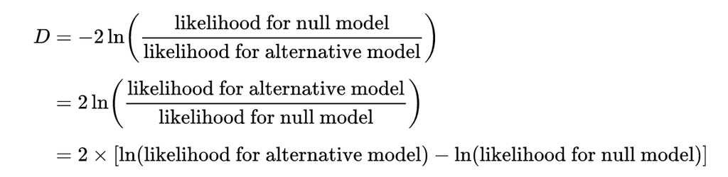

$D \sim \chi^2(df)$, df= df(alter)-df(null)

#### AIC, BIC

Akaike Information Criterion and Bayesian Information Criterion take number of parameters into account to protect against overfitted models.

$AIC=2\times(k-\log L)$, $BIC=k\times \log(n) - 2\times \log L$

k=number of parameters, n=sample size

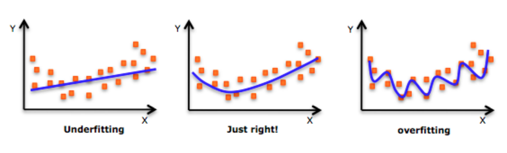

#### Stepwise Regression

`library(MASS)`

`step <- stepAIC(full, direction="both")` #選擇AIC值越小的模型

`step$anova # display results`

#### Multicollinearity: VIF

car::vif(model)

http://www.r-tutor.com/elementary-statistics/simple-linear-regression

#### Transformation

非線性關係時，或error term不符合規定，需transform

- Quadratic: $\hat{Y}_i=\beta_0+\beta_1X_1+\beta_2X_1^2$
- log:
  - $Y=\beta_0+\beta_1\sqrt{X_1}$ (if not equal variance)
  - $\log Y_i= \log \beta_0 +\beta_1 \log X_1 +\beta_2 \log X_2 +\log \epsilon$ (base 10 log)
  - $\log Y_i =\beta_0 + \beta_1 X_1 +\beta_2 X_2 +\log \epsilon$ (nature log)

Ref: http://rcompanion.org/handbook/I_12.html

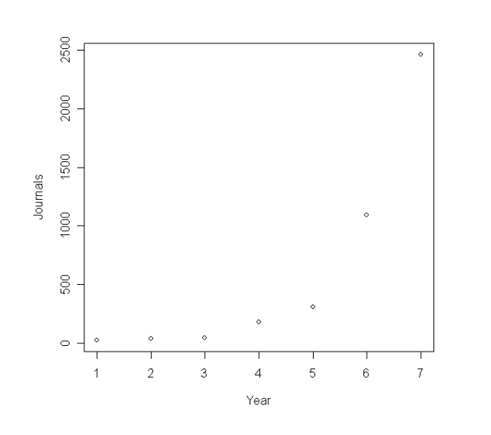

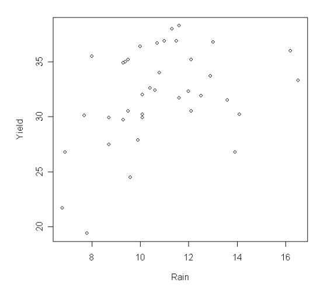

# Remark:

| R codes in lm() | Meaning |
| --- | --- |
| Y~A | $Y=\beta_0+\beta_1A$ |
| Y~A-1 | $Y=\beta_1A$ |
| Y~A:B | $Y=\beta_0+\beta_1AB$ |
| Y~A $\times$ B | $Y=\beta_0+\beta_1A+\beta_2B+\beta_3AB$ |
| Y~$(A+B+C)^2$ | $Y=\beta_0+\beta_1A+\beta_2B+\beta_3C+\beta_4AB+\beta_5AC+\beta_6BC$ |

| Under fitting | Over fitting |
| --- | --- |
| 低複雜 | 高複雜 |
| high bias | low bias |
| low variance | high variance |

當解釋變數為類別變數時，在迴歸模型分析中會將其轉換為虛擬變數(dummy variable)。R中可直接將這變數加上factor()放入模型中。e.g.商萊想預測在政大開便利商店月收入：

Y:月收入， X:超商：7-11, 全家, 萊爾富, 商萊。

`lm(Ｙ~factor(Ｘ))`.會出來3個fitted coefficients＋intercept：$\hat{y}=\beta_0+\beta_1 factor(x=萊)+\beta_2 factor(x=全)+\beta_3 factor(x=711)$

$\beta_1, \beta_2, \beta_3$係數的解釋方法皆為與商萊比較的差異。例如，與商萊比，7-11每月平均收入多$\beta_3$

可用`contrasts(factor(X))`，看R怎麼編碼dummy variables，若要指定reference group (baseline)：`lm(Y ~ relevel(factor(X), ref = "商萊"))`

#### Exercise sale資料

Using the dataset *sale.csv*

變數解釋

Store (A,B,C)

Month (Jan~Dec)

Type (self自營、company加盟)

Sale 營業額

ADprice 廣告額

1. 先用EDA了解資料 (營業額根據store、type、月份的變化)
2. Fit a regression model to predict the sales for different stores.

#### Exercise 紅酒資料

Using the dataset *wine.csv*,

1. construct a linear model to predict flavanoid(類黃酮) content across cultivars(品種), while controlling for total phenol content(苯酚含量). Additionally visualize your data with a scatterplot, colored by cultivar.
2. construct a linear model to predict wine Color from all other columns as independent predictors.
3. use stepwise method to find a best subset of variables to predict wine Color.

`wine$Cultivar <- factor(wine$Cultivar)`